# Comparing Burnes’ Pitching Performance: A Deep Dive into 2018-2019 vs 2020-2024

# Research Question

Corbin Burnes transformed his pitching repertoire by using cutter instead of 4-seam fastball in 2020, a decision that significantly impacted his performance. My research investigates the changes in Burnes’ pitching stats before and after this transition, focusing on key metrics such as Earned Run Average (ERA), FIP, WHIP, and Walks per Nine Innings (BB9). By examining how his pitch repertoire evolved and its effect on his overall performance, this analysis aims to highlight the effectiveness of introducing the cutter into his arsenal, showing the proof that one pitcher’s career could be changed dramatically due to the addition of one suitable pitch.

# Narrative Text

**Reason why I want to investigate this topic**: The primary motivation behind analyzing Corbin Burnes’ pitching transformation is to understand how a single pitch—the cutter—can redefine a player’s career. Burnes’ performance in 2018-2019 was disappointing, but his reinvention as a pitcher in 2020-2024 showcases the profound impact of adapting and evolving in professional sports. By diving into his statistical changes, I hope to uncover the specific ways the cutter improved his overall effectiveness and contributed to his dominance.

**One significant technical challenge**: One of the most significant challenges in this project was ensuring the accuracy and consistency of the data. Burnes’ pitching stats were split across two distinct time periods: 2018-2019 and 2020-2024. Merging these datasets while maintaining the integrity of key metrics required careful cleaning and validation. Additionally, selecting relevant metrics to evaluate his performance—while avoiding information overload—demanded thoughtful consideration and data manipulation.

**Significant findings or conclusions**: This detailed analysis of Corbin Burnes’ transformation from his pre-cutter (2018-2019) to post-cutter (2020-2024) seasons highlights several key areas of improvement following the introduction of the cutter:

1. Pitch Mix Evolution: In the pre-cutter period, Burnes predominantly relied on a two-pitch mix of the 4-seam fastball (54.3%) and slider (31.9%). However, from 2020 onwards, Burnes replaced the 4-seam fastball with the cutter, which became his primary pitch (50.5%). This shift allowed Burnes to incorporate a more varied pitch repertoire, including an increased use of breaking balls such as the curveball, changeup, and sinker, which complemented his cutter effectively.
2. Improved Performance Metrics: Batting Average (BA): Burnes saw a notable decrease in opponents’ batting averages across nearly all pitches after adding the cutter. The changeup and curveball, in particular, showed marked improvements, with batting averages against them significantly lower in the post-cutter seasons.
3. Overall Pitching Effectiveness: Burnes’ transformation into an elite pitcher can be attributed to the incorporation of the cutter, which allowed him to improve across multiple metrics, including ERA, FIP, HR/9, K/9, and WHIP. His pitch mix diversification and increased reliance on the cutter helped him become a more unpredictable and dominant force on the mound.

**Conclusion**: Corbin Burnes’ adoption of the cutter marked a pivotal turning point in his pitching career, significantly enhancing his performance and transforming him into one of the top starting pitchers in Major League Baseball. The cutter not only improved key metrics such as BA, SLG, and K/9 but also facilitated a more diverse and effective pitch selection. Burnes’ evolution exemplifies the importance of adaptability and innovation in professional baseball, demonstrating how the continuous refinement of one’s pitch mix can lead to sustained success and dominance on the mound.

**KEY Stats in this Project**

*ERA (Earned Run Average)* A widely-used metric that measures a pitcher’s ability to prevent earned runs. It reflects the overall effectiveness in managing opposing offenses.

*BB/9 (Walks per Nine Innings)* This stat highlights a pitcher’s control by showing how many walks they allow per nine innings. Lowering BB/9 indicates better command and fewer free passes to batters.

*FIP (Fielding Independent Pitching)* FIP isolates a pitcher’s performance by focusing on factors under their control—strikeouts, walks, and home runs—while removing fielding influence. It gives a clearer picture of Burnes’ pitching skills.

*WHIP (Walks + Hits per Inning Pitched)* A key metric for assessing how effectively a pitcher prevents batters from reaching base. WHIP combines walks and hits, providing an overview of a pitcher’s ability to limit base runners.

**Pitching Effectiveness**

*HR/9 (Home Runs per Nine Innings)* HR/9 measures a pitcher’s ability to prevent home runs, which limits extra-base hits and runs. Comparing pre- and post-cutter HR/9 gives insight into whether Burnes improved at limiting long balls after adding the cutter.

*K/9 (Strikeouts per Nine Innings)* K/9 tracks a pitcher’s strikeout rate. After adding the cutter, K/9 can show how the pitch contributed to Burnes’ ability to generate strikeouts.

**Control and Command**

*BA (Batting Average Against)* BA Against measures how successful batters are at making contact with the pitcher’s pitches. A decrease in BA after adding the cutter signals improved pitching performance.

*SLG (Slugging Percentage Against)* SLG shows how many extra-base hits batters are able to produce. A lower SLG indicates that Burnes improved at limiting hard contact and extra-base hits after incorporating the cutter.

**Strikeouts and Contact**

*Whiffs (Swinging Strikes)* Tracks how often batters swing and miss at Burnes’ pitches. An increase in whiffs suggests that his pitches, particularly the cutter, are generating more swings and misses.

**Other Metrics**

BK (Balks): A pitcher’s illegal motion that allows runners to advance.

BF (Batters Faced): Total number of batters a pitcher faces during an outing.

WP (Wild Pitches): The number of pitches the catcher cannot handle, allowing runners to advance.

```r
library(tidyverse)
```

```r
library(dplyr)
library(tidyr)
library(ggplot2)

Burnes_1819 <- read.csv("/Users/jjwee/Downloads/Burnes2018-2019.csv")
Burnes_2024 <- read.csv("/Users/jjwee/Downloads/Burnes2020-2024.csv")
```

This section loads the required libraries (tidyverse, dplyr, tidyr, and ggplot2) and reads two CSV files containing Corbin Burnes’ pitching data for the 2018-2019 and 2020-2024 periods. The data will be used for further analysis to compare Burnes’ pitching performance before and after the introduction of his cutter.

```r
colnames(Burnes_1819)
```

```
##  [1] "Season"        "Age"           "Team"          "League"
##  [5] "WAR"           "W"             "L"             "W.L."
##  [9] "ERA"           "G"             "GS"            "GF"
## [13] "CG"            "SHO"           "SV"            "IP"
## [17] "H"             "R"             "ER"            "HR"
## [21] "BB"            "IBB"           "SO"            "HBP"
## [25] "BALKS"         "WILD.PITCHES"  "BATTERS.FACED" "ERA."
## [29] "FIP"           "WHIP"          "H.9"           "HR.9"
## [33] "BB.9"          "SO.9"          "SO.BB"
```

```r
colnames(Burnes_2024)
```

```
##  [1] "Season"        "Age"           "Team"          "League"
##  [5] "WAR"           "W"             "L"             "W.L."
##  [9] "ERA"           "G"             "GS"            "GF"
## [13] "CG"            "SHO"           "SV"            "IP"
## [17] "H"             "R"             "ER"            "HR"
## [21] "BB"            "IBB"           "SO"            "HBP"
## [25] "BALKS"         "WILD.PITCHES"  "BATTERS.FACED" "ERA."
## [29] "FIP"           "WHIP"          "H.9"           "HR.9"
## [33] "BB.9"          "SO.9"          "SO.BB"
```

```r
# Add a new column for period and combine the data
Burnes_1819 <- Burnes_1819 %>%
  mutate(period = "2018-2019")

Burnes_2024 <- Burnes_2024 %>%
  mutate(period = "2020-2024")

# Combine the two datasets
combined_data <- bind_rows(Burnes_1819, Burnes_2024)

# Check the structure of the combined data
colnames(combined_data)
```

```
##  [1] "Season"        "Age"           "Team"          "League"
##  [5] "WAR"           "W"             "L"             "W.L."
##  [9] "ERA"           "G"             "GS"            "GF"
## [13] "CG"            "SHO"           "SV"            "IP"
## [17] "H"             "R"             "ER"            "HR"
## [21] "BB"            "IBB"           "SO"            "HBP"
## [25] "BALKS"         "WILD.PITCHES"  "BATTERS.FACED" "ERA."
## [29] "FIP"           "WHIP"          "H.9"           "HR.9"
## [33] "BB.9"          "SO.9"          "SO.BB"         "period"
```

This code adds a new period column to each dataset to distinguish between the 2018-2019 (pre-cutter) and 2020-2024 (post-cutter) periods. The datasets are then merged with bind_rows() into a single dataset for analysis. Finally, the column names of the combined dataset are checked to ensure consistency and clarity.

```r
# Calculate averages for each metric within each period
combined_data_avg <- combined_data %>%
  group_by(period) %>%
  summarise(
    ERA = mean(ERA, na.rm = TRUE),
    K9 = mean(SO.9, na.rm = TRUE),
    BB9 = mean(BB.9, na.rm = TRUE),
    FIP = mean(FIP, na.rm = TRUE),
    WHIP = mean(WHIP, na.rm = TRUE),
    HR9 = mean(HR.9, na.rm = TRUE),
    )

# Check the calculated averages
glimpse(combined_data_avg)
```

```
## Rows: 2
## Columns: 7
## $ period <chr> "2018-2019", "2020-2024"
## $ ERA    <dbl> 5.715, 2.758
## $ K9     <dbl> 10.60, 10.88
## $ BB9    <dbl> 3.15, 2.60
## $ FIP    <dbl> 4.940, 2.832
## $ WHIP   <dbl> 1.4185, 1.0184
## $ HR9    <dbl> 2.00, 0.74
```

The average values for key pitching metrics (ERA, K/9, BB/9, FIP, WHIP, HR/9) were calculated for each period (2018-2019 and 2020-2024). The group_by() function was used to separate the data by period, and then summarise() was applied to compute the mean for each metric. Afterward, glimpse() was used to review the results and ensure accuracy.

```r
# Reshape the average data to long format
combined_data_avg_long <- combined_data_avg %>%
  pivot_longer(cols = c(ERA, K9, BB9, FIP, WHIP, HR9),
               names_to = "metric", values_to = "value")

# Check the reshaped data
glimpse(combined_data_avg_long)
```

```
## Rows: 12
## Columns: 3
## $ period <chr> "2018-2019", "2018-2019", "2018-2019", "2018-2019", "2018-2019"…
## $ metric <chr> "ERA", "K9", "BB9", "FIP", "WHIP", "HR9", "ERA", "K9", "BB9", "…
## $ value  <dbl> 5.7150, 10.6000, 3.1500, 4.9400, 1.4185, 2.0000, 2.7580, 10.880…
```

The dataset containing the average pitching metrics (ERA, K/9, BB/9, FIP, WHIP, HR/9) was reshaped from a wide to a long format using pivot_longer(). This transformation improves the data’s suitability for visualization and comparison. The metric column now holds the names of the pitching metrics, while the value column contains their corresponding average values. After reshaping, glimpse() was used to verify the structure and confirm that the transformation was applied correctly.

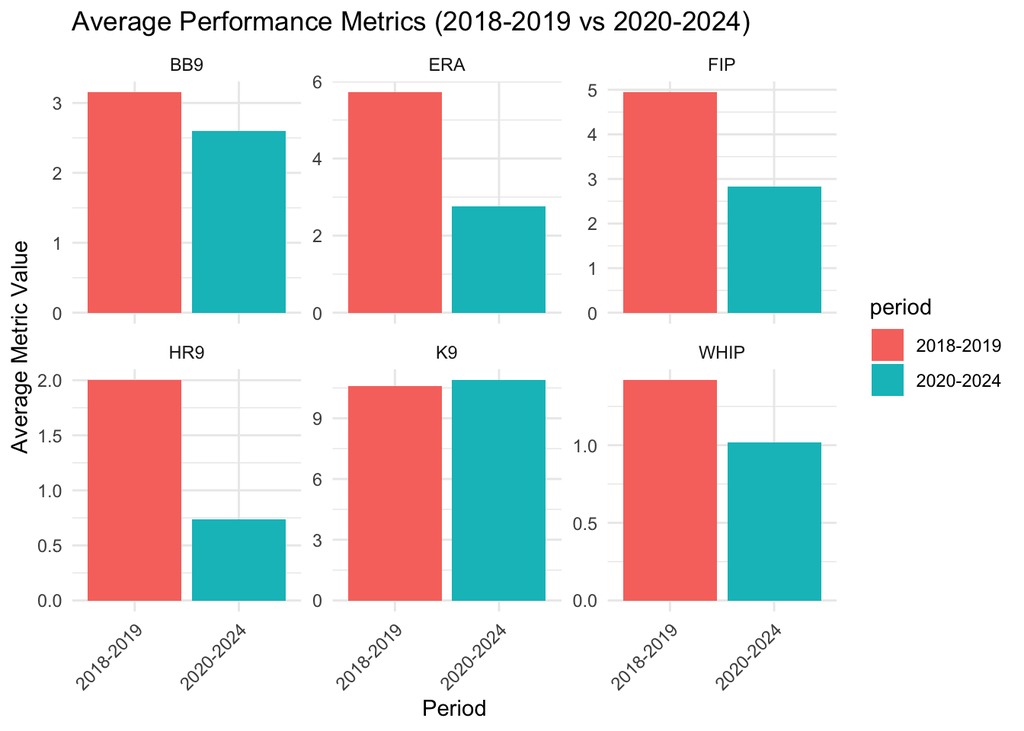

```r
# Visualization: Comparing average metrics for 2018-2019 vs 2020-2024
ggplot(combined_data_avg_long, aes(x = period, y = value, fill = period)) +
  geom_bar(stat = "identity", position = "dodge") +
  facet_wrap(~ metric, scales = "free_y") +
  labs(title = "Average Performance Metrics (2018-2019 vs 2020-2024)",
       x = "Period", y = "Average Metric Value") +
  theme_minimal() +
  theme(axis.text.x = element_text(angle = 45, hjust = 1))
```

This bar chart compares six pitching metrics (BB/9, ERA, FIP, HR/9, K/9, and WHIP) between Corbin Burnes’ pre-cutter seasons (2018-2019) and post-cutter seasons (2020-2024). The data highlights significant improvements in BB/9, ERA, FIP, HR/9, and WHIP during the post-cutter period, while K/9 saw a slight increase. These improvements reflect Burnes’ transformation and success after effectively incorporating the cutter into his repertoire in 2020.

## To explore the significant contrast in Corbin Burnes’ pitching stats between the 2018-2019 and 2020-2024 seasons, I analyzed his pitch repertoire. Understanding the evolution of his pitch selection offers valuable insight into the transformation that contributed to his remarkable improvement.

```r
Burnes_1819_fastball <- read.csv("/Users/jjwee/Downloads/Burnes_1819_fb.csv")
Burnes_1819_sinker<- read.csv("/Users/jjwee/Downloads/Burnes_1819_sinker.csv")
Burnes_1819_cutter<- read.csv("/Users/jjwee/Downloads/Burnes_1819_cutter.csv")
Burnes_1819_changeup<- read.csv("/Users/jjwee/Downloads/Burnes_1819_changeup.csv")
```

```r
Burnes_1819_curve<- read.csv("/Users/jjwee/Downloads/Burnes_1819_curve.csv")
Burnes_1819_slider<- read.csv("/Users/jjwee/Downloads/Burnes_1819_slider.csv")
Burnes_2024_fastball <- read.csv("/Users/jjwee/Downloads/Burnes_2024_fb.csv")
Burnes_2024_sinker <- read.csv("/Users/jjwee/Downloads/Burnes_2024_sinker.csv")
Burnes_2024_cutter <- read.csv("/Users/jjwee/Downloads/Burnes_2024_cutter.csv")
Burnes_2024_changeup <- read.csv("/Users/jjwee/Downloads/Burnes_2024_changeup.csv")
Burnes_2024_curve <- read.csv("/Users/jjwee/Downloads/Burnes_2024_curve.csv")
Burnes_2024_slider <- read.csv("/Users/jjwee/Downloads/Burnes_2024_slider.csv")
Burnes_2024_sweeper <- read.csv("/Users/jjwee/Downloads/Burnes_2024_sweeper.csv")
```

Corbin Burnes’ pitching data for the 2018-2019 and 2020-2024 periods was imported, focusing on different pitch types. The datasets include fastball, sinker, cutter, changeup, curve, slider, and sweeper pitches. Each pitch type’s data from both periods was stored in separate CSV files and loaded using read.csv(). This setup enables a more detailed, pitch-specific analysis across the two distinct time frames (pre- and post-cutter).

```r
# Add period and pitch type labels to each dataset
Burnes_1819_fastball <- Burnes_1819_fastball %>% mutate(period = "2018-2019", pitch_type = "Fastball")
Burnes_1819_sinker <- Burnes_1819_sinker %>% mutate(period = "2018-2019", pitch_type = "Sinker")
Burnes_1819_cutter <- Burnes_1819_cutter %>% mutate(period = "2018-2019", pitch_type = "Cutter")
Burnes_1819_changeup <- Burnes_1819_changeup %>% mutate(period = "2018-2019", pitch_type = "Changeup")
Burnes_1819_curve <- Burnes_1819_curve %>% mutate(period = "2018-2019", pitch_type = "Curve")
Burnes_1819_slider <- Burnes_1819_slider %>% mutate(period = "2018-2019", pitch_type = "Slider")

Burnes_2024_fastball <- Burnes_2024_fastball %>% mutate(period = "2020-2024", pitch_type = "Fastball")
Burnes_2024_sinker <- Burnes_2024_sinker %>% mutate(period = "2020-2024", pitch_type = "Sinker")
Burnes_2024_cutter <- Burnes_2024_cutter %>% mutate(period = "2020-2024", pitch_type = "Cutter")
Burnes_2024_changeup <- Burnes_2024_changeup %>% mutate(period = "2020-2024", pitch_type = "Changeup")
Burnes_2024_curve <- Burnes_2024_curve %>% mutate(period = "2020-2024", pitch_type = "Curve")
Burnes_2024_slider <- Burnes_2024_slider %>% mutate(period = "2020-2024", pitch_type = "Slider")
Burnes_2024_sweeper <- Burnes_2024_sweeper %>% mutate(period = "2020-2024", pitch_type = "Sweeper")

# Combine all data
Burnes_pitch_data <- bind_rows(
  Burnes_1819_fastball, Burnes_1819_sinker, Burnes_1819_cutter, Burnes_1819_changeup, Burnes_1819_curve, Burnes_1819_slider,
  Burnes_2024_fastball, Burnes_2024_sinker, Burnes_2024_cutter, Burnes_2024_changeup, Burnes_2024_curve, Burnes_2024_slider, Burnes_2024_sweeper
)

# View combined data
glimpse(Burnes_pitch_data)
```

```
## Rows: 13
## Columns: 72
## $ pitches                   <int> 800, 34, 10, 36, 108, 470, 76, 1263, 6542, 1…
## $ player_id                 <int> 669203, 669203, 669203, 669203, 669203, 6692…
## $ player_name               <chr> "Burnes, Corbin", "Burnes, Corbin", "Burnes,…
## $ total_pitches             <int> 1474, 1474, 1474, 1474, 1474, 1474, 12953, 1…
## $ pitch_percent             <dbl> 54.3, 2.3, 0.7, 2.4, 7.3, 31.9, 0.6, 9.8, 50…
## $ ba                        <dbl> 0.317, 0.250, 0.333, 0.333, 0.545, 0.191, 0.…
## $ iso                       <dbl> 0.256, 0.375, 0.000, 0.333, 0.182, 0.174, 0.…
## $ babip                     <dbl> 0.333, 0.143, 1.000, 0.667, 0.545, 0.321, 0.…
## $ slg                       <dbl> 0.573, 0.625, 0.333, 0.667, 0.727, 0.365, 0.…
## $ woba                      <dbl> 0.402, 0.351, 0.390, 0.409, 0.553, 0.255, 0.…
## $ xwoba                     <dbl> 0.388, 0.428, 0.260, 0.255, 0.476, 0.238, 0.…
## $ xba                       <dbl> 0.300, 0.353, 0.120, 0.158, 0.493, 0.183, 0.…
## $ hits                      <int> 63, 2, 1, 3, 6, 22, 7, 66, 355, 59, 63, 56, 4
```

[output cut: 59 more lines]

This code adds period and pitch type labels to each dataset, indicating whether the data is from the 2018-2019 or 2020-2024 period and specifying which pitch type (e.g., Fastball, Sinker, Cutter, etc.) each row of data corresponds to. After labeling, the datasets for each pitch type and period are combined into one unified dataset using bind_rows(). The resulting Burnes_pitch_data allows for pitch-specific analysis over the two periods. Finally, glimpse() is used to inspect the structure of the combined dataset and ensure it has been successfully merged.

```r
Burnes_pitch_repertoire <- Burnes_pitch_data %>%
  mutate(usage_percentage = case_when(
    period == "2018-2019" & pitch_type == "Fastball" ~ 54.3,
    period == "2018-2019" & pitch_type == "Sinker" ~ 2.3,
    period == "2018-2019" & pitch_type == "Cutter" ~ 0.7,
    period == "2018-2019" & pitch_type == "Changeup" ~ 2.4,
    period == "2018-2019" & pitch_type == "Curve" ~ 7.3,
    period == "2018-2019" & pitch_type == "Slider" ~ 31.9,
    period == "2020-2024" & pitch_type == "Fastball" ~ 0.6,
    period == "2020-2024" & pitch_type == "Sinker" ~ 9.8,
    period == "2020-2024" & pitch_type == "Cutter" ~ 50.5,
    period == "2020-2024" & pitch_type == "Changeup" ~ 10.5,
    period == "2020-2024" & pitch_type == "Curve" ~ 18.1,
    period == "2020-2024" & pitch_type == "Slider" ~ 9.0,
    period == "2020-2024" & pitch_type == "Sweeper" ~ 1.5,
    TRUE ~ NA_real_
  ))
```

This code adds a new column, usage_percentage, to the Burnes_pitch_data dataset, representing the usage percentage of each pitch type for Burnes during the 2018-2019 and 2020-2024 periods. The case_when() function assigns specific percentages based on the pitch type and period. The resulting Burnes_pitch_repertoire dataset includes this additional information, making it ready for further analysis.

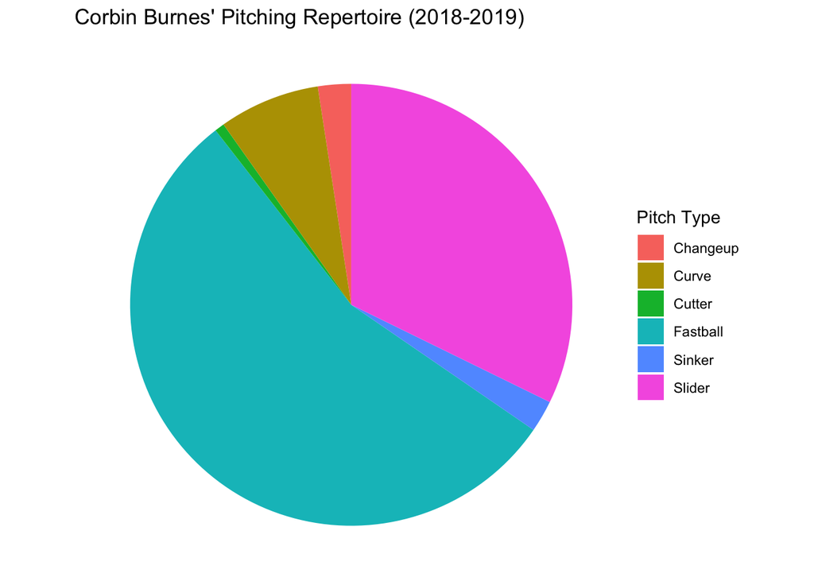

```r
# Filter data for each period
pitch_data_1819 <- Burnes_pitch_repertoire %>% filter(period == "2018-2019")
pitch_data_2024 <- Burnes_pitch_repertoire %>% filter(period == "2020-2024")

# Pie chart for 2018-2019
pie_1819 <- ggplot(pitch_data_1819, aes(x = "", y = usage_percentage, fill = pitch_type)) +
  geom_bar(stat = "identity", width = 1) +
  coord_polar(theta = "y") +
  labs(
    title = "Corbin Burnes' Pitching Repertoire (2018-2019)",
    fill = "Pitch Type"
  ) +
  theme_void()

# Print the pie charts
pie_1819
```

This pie chart reveals that during the 2018-2019 seasons, Corbin Burnes heavily used his 4-seam fastball (54.3%) and slider (31.9%), which together accounted for over 85% of his pitch usage. While he occasionally mixed a curveball (7.3%), his cutter (0.7%), sinker (2.3%), and changeup (2.4%) were rarely thrown. This highlights that Burnes primarily relied on a two-pitch mix centered around his 4-seam fastball and slider.

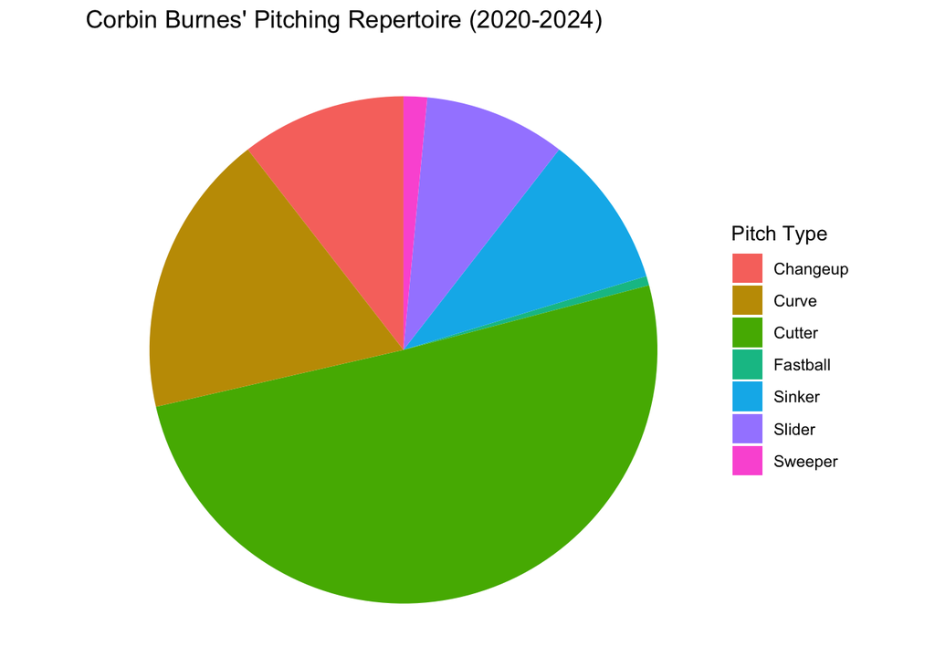

```r
# Pie chart for 2020-2024
pie_2024 <- ggplot(pitch_data_2024, aes(x = "", y = usage_percentage, fill = pitch_type)) +
  geom_bar(stat = "identity", width = 1) +
  coord_polar(theta = "y") +
  labs(
    title = "Corbin Burnes' Pitching Repertoire (2020-2024)",
    fill = "Pitch Type"
  ) +
  theme_void()

# Print the pie charts
pie_2024
```

This pie chart highlights a dramatic shift in Corbin Burnes’ pitch selection during his post-cutter seasons (2020-2024). The cutter became his primary pitch, accounting for 50.5% of his usage, replacing the 4-seam fastball, which he used over 50% of the time in 2018-2019 but almost entirely abandoned, especially in 2023-2024. Burnes also expanded his repertoire significantly, increasing his reliance on breaking balls such as the changeup (10.5%), curveball (18.1%), and sinker (9.8%). Meanwhile, his slider usage sharply declined. This evolution underscores Burnes’ transition from a two-pitch style (fastball and slider) to a more varied and effective pitch mix.

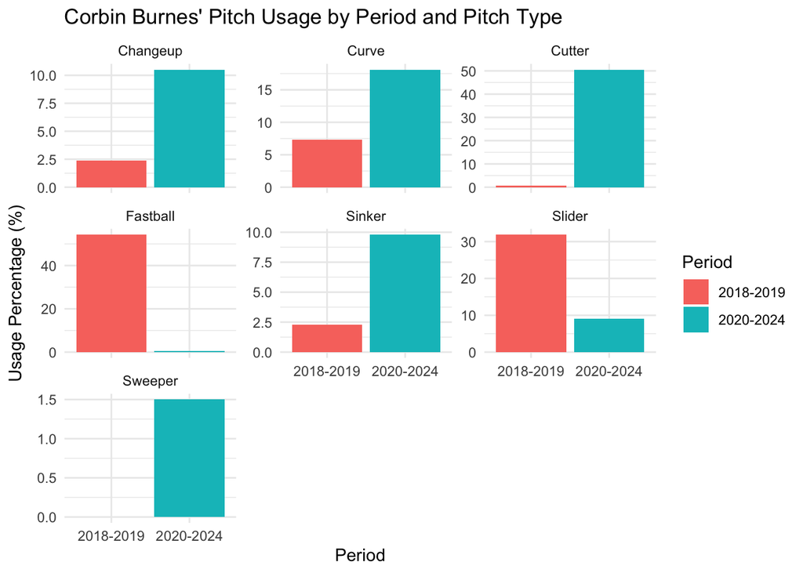

```r
ggplot(Burnes_pitch_repertoire, aes(x = period, y = usage_percentage, fill = period)) +
  geom_bar(stat = "identity") +
  facet_wrap(~pitch_type, scales = "free_y") +
  labs(
    title = "Corbin Burnes' Pitch Usage by Period and Pitch Type",
    x = "Period",
    y = "Usage Percentage (%)",
    fill = "Period"
  ) +
  theme_minimal()
```

This bar chart compares Corbin Burnes’ pitch usage across different periods. As shown in the previous pie chart, Burnes primarily relied on the 4-seam fastball and slider in the pre-cutter seasons, with limited usage of the sinker, cutter, changeup, and curveball. However, from 2020-2024, Burnes significantly diversified his pitch selection, increasing his usage of the sinker, curveball, cutter, and changeup. He replaced the 4-seam fastball with the cutter and integrated it with a wider variety of pitches. This evolution helped Burnes become one of the top starting pitchers in Major League Baseball.

## Given the huge difference in Corbin Burnes’ pitching repertoire between the pre-cutter and post-cutter seasons, I analyzed the pitching metrics for each of his pitches to understand how the shift in repertoire influenced his performance.

```r
Burnes_pitch_performance <- Burnes_pitch_repertoire %>%
  group_by(period, pitch_type) %>%
  summarise(
    avg_BB9 = mean(bb_percent, na.rm = TRUE),
    avg_ba = mean(ba, na.rm = TRUE),
    avg_slg = mean(slg, na.rm = TRUE),
    avg_spinrate = mean(spin_rate, na.rm = TRUE),
    avg_whiffs = mean(whiffs, na.rm = TRUE)
  )
# Filter only the desired metrics (avg_ba, avg_slg, avg_whiffs)
metrics_of_interest <- c("avg_ba", "avg_slg", "avg_whiffs")

Burnes_pitch_performance_long <- Burnes_pitch_performance %>%
  gather(key = "metric", value = "value", avg_BB9:avg_whiffs) %>%
  filter(metric %in% metrics_of_interest)  # Filter for the selected metrics
```

This code calculates and reshapes pitching performance data for Burnes, focusing on three key metrics: batting average (BA), slugging percentage (SLG), and whiff rate. It computes the average values for these metrics by pitch type and period, then reshapes the data into a long format for easier comparison across the two periods (2018-2019 and 2020-2024).

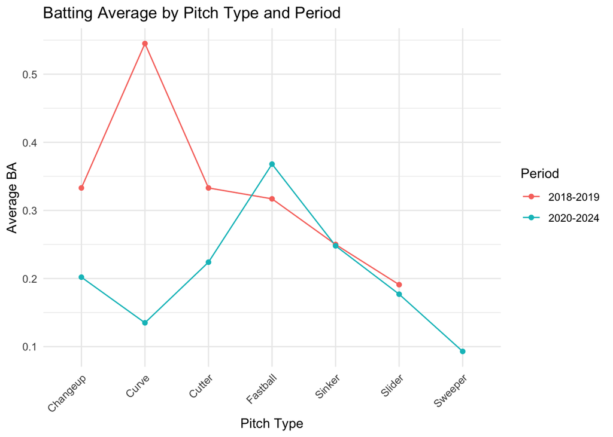

```r
# Plot 1: Batting Average (avg_ba)
ggplot(Burnes_pitch_performance_long %>% filter(metric == "avg_ba"), aes(x = pitch_type, y = value, color = period, group = period)) +
  geom_line() +
  geom_point() +
  labs(
    title = "Batting Average by Pitch Type and Period",
    x = "Pitch Type",
    y = "Average BA",
    color = "Period"
  ) +
  theme_minimal() +
  theme(axis.text.x = element_text(angle = 45, hjust = 1))
```

In contrast, every pitch in Burnes’ 2020-2024 repertoire showed a lower batting average compared to the pre-cutter seasons, except for the fastball, which he used much less. Notably, hitters’ batting averages against Burnes’ changeup and curveball significantly dropped after he added the cutter to his repertoire. This illustrates how incorporating the cutter helped improve Burnes’ performance and contributed to his career success.

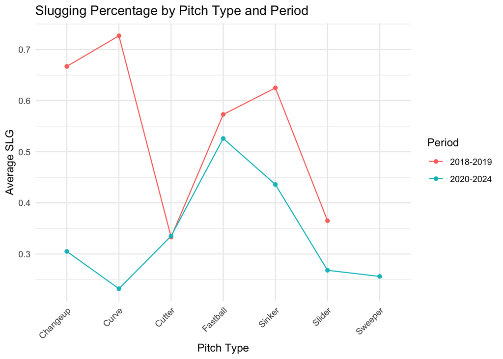

```r
# Plot 2: Slugging Percentage (avg_slg)
ggplot(Burnes_pitch_performance_long %>% filter(metric == "avg_slg"), aes(x = pitch_type, y = value, color = period, group = period)) +
  geom_line() +  # Line graph
  geom_point() +  # Add points
  labs(
    title = "Slugging Percentage by Pitch Type and Period",
    x = "Pitch Type",
    y = "Average SLG",
    color = "Period"
  ) +
  theme_minimal() +
  theme(axis.text.x = element_text(angle = 45, hjust = 1))
```

This visualization shows the slugging percentage of hitters faced by Corbin Burnes during the pre-cutter (2018-2019) and post-cutter (2020-2024) seasons. As with the batting average graph, the slugging percentage against Burnes’ changeup and curveball was significantly higher in the pre-cutter seasons compared to the post-cutter seasons. In fact, the slugging percentages against his fastball, sinker, and slider were also higher in the pre-cutter period. This indicates that Burnes’ pitching was less effective before he adapted the cutter into his arsenal.

In the post-cutter seasons, Burnes effectively utilized his pitch repertoire, significantly lowering hitters’ slugging percentages, especially on the changeup, curveball, and sinker — pitches he relied on much more in 2020-2024. The slugging percentage against his cutter was nearly identical in both periods, but since the cutter’s usage increased dramatically in the post-cutter seasons, it demonstrates that Burnes adapted and used his pitches more effectively.

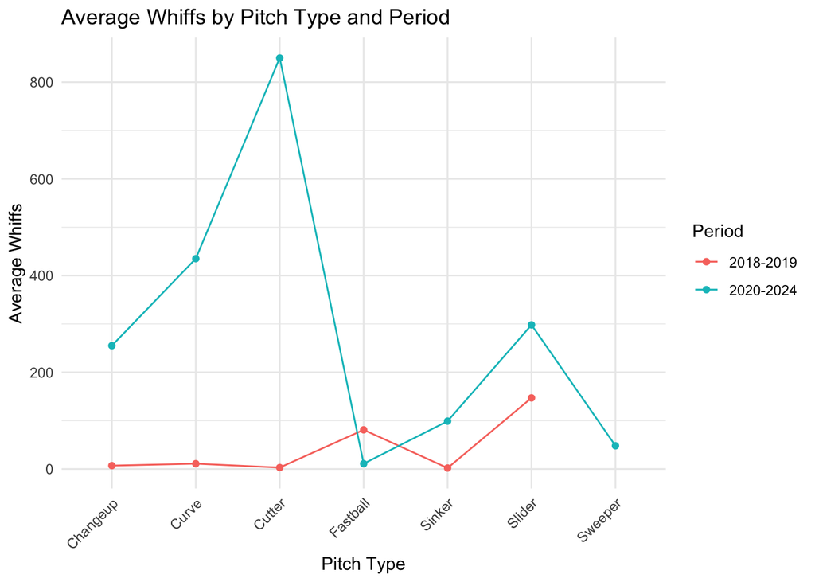

```r
# Plot: Average Whiffs (avg_whiffs)
ggplot(Burnes_pitch_performance_long %>% filter(metric == "avg_whiffs"), aes(x = pitch_type, y = value, color = period, group = period)) +
  geom_line() +
  geom_point() +
  labs(
    title = "Average Whiffs by Pitch Type and Period",
    x = "Pitch Type",
    y = "Average Whiffs",
    color = "Period"
  ) +
  theme_minimal() +
  theme(axis.text.x = element_text(angle = 45, hjust = 1))
```

This visualization shows the whiffs of hitters faced by Corbin Burnes during the pre-cutter (2018-2019) and post-cutter (2020-2024) seasons.

In the pre-cutter seasons, Burnes generated very few whiffs on his changeup, curveball, and sinker. Most of his whiffs came from the fastball and slider, which were the two pitches he relied on the most.

However, from 2020-2024, after Burnes incorporated the cutter into his arsenal and used it more than 50% of the time, he saw a significant increase in whiffs. The cutter became his most effective pitch for generating whiffs. Additionally, he recorded many more whiffs on his changeup, curveball, slider, and sinker.

It’s important to note the whiffs against the slider. Despite using the slider less (dropping from 32% usage to 9%), Burnes still generated 151 more whiffs on it in the post-cutter seasons compared to the pre-cutter seasons.

This line graph demonstrates that Burnes became a much more effective all-around pitcher by adding the cutter to his repertoire, replacing the 4-seam fastball with the cutter, and adjusting his pitch mix by reducing slider usage and increasing reliance on other breaking balls, such as the changeup, curveball, and sinker.